# Multivariate Assignment

Lexie DelViscio and Francesca Dellacqua

2/12/2022

# Multivariate Assignment

```r
library(vegan)
data(dune)
data(dune.env)
head(dune)
```

```
##   Achimill Agrostol Airaprae Alopgeni Anthodor Bellpere Bromhord Chenalbu
## 1        1        0        0        0        0        0        0        0
## 2        3        0        0        2        0        3        4        0
## 3        0        4        0        7        0        2        0        0
## 4        0        8        0        2        0        2        3        0
## 5        2        0        0        0        4        2        2        0
## 6        2        0        0        0        3        0        0        0
##   Cirsarve Comapalu Eleopalu Elymrepe Empenigr Hyporadi Juncarti Juncbufo
## 1        0        0        0        4        0        0        0        0
## 2        0        0        0        4        0        0        0        0
## 3        0        0        0        4        0        0        0        0
## 4        2        0        0        4        0        0        0        0
## 5        0        0        0        4        0        0        0        0
## 6        0        0        0        0        0        0        0        0
##   Lolipere Planlanc Poaprat Poatriv Ranuflam Rumeacet Sagiproc Salirepe
## 1        7        0       4       2        0        0        0        0
## 2        5        0       4       7        0        0        0        0
## 3        6        0       5       6        0        0        0        0
## 4        5        0       4       5        0        0        5        0
## 5        2        5       2       6        0        5        0        0
## 6        6        5       3       4        0        6        0        0
##   Scorautu Trifprat Trifrepe Vicilath Bracruta Callcusp
## 1        0        0        0        0        0        0
## 2        5        0        5        0        0        0
## 3        2        0        2        0        2        0
## 4        2        0        1        0        2        0
## 5        3        2        2        0        2        0
## 6        3        5        5        0        6        0
```

```r
head(dune.env)
```

```
##    A1 Moisture Management      Use Manure
## 1 2.8        1         SF Haypastu      4
## 2 3.5        1         BF Haypastu      2
## 3 4.3        2         SF Haypastu      4
## 4 4.2        2         SF Haypastu      4
## 5 6.3        1         HF Hayfield      2
## 6 4.3        1         HF Haypastu      2
```

```r
names(dune) # species
```

```
##  [1] "Achimill" "Agrostol" "Airaprae" "Alopgeni" "Anthodor" "Bellpere"
##  [7] "Bromhord" "Chenalbu" "Cirsarve" "Comapalu" "Eleopalu" "Elymrepe"
## [13] "Empenigr" "Hyporadi" "Juncarti" "Juncbufo" "Lolipere" "Planlanc"
## [19] "Poaprat"  "Poatriv"  "Ranuflam" "Rumeacet" "Sagiproc" "Salirepe"
## [25] "Scorautu" "Trifprat" "Trifrepe" "Vicilath" "Bracruta" "Callcusp"
```

```r
names(dune.env) # variable
```

```
## [1] "A1"         "Moisture"   "Management" "Use"        "Manure"
```

# 1) Describe how you interpret the graphic. What is the goal of creating such a plot? Does this analysis suggest any interesting findings with respect to the dune vegetation?

```r
par(mfrow=(c(1,2)))
dune_mds = metaMDS(dune)
```

```
## *** Solution reached
```

```r
plot(dune_mds, type='n')
text(dune_mds, 'sp', cex=.5)
# generate vector of colors
color_vect = rev(terrain.colors(6))[-1]
points(dune_mds, 'sites', pch=19,
       col=color_vect[dune.env$Moisture])
legend('topright', paste("Moisture =", 1:5, sep=''),
       col=color_vect, pch=19)

dune_mds
```

```
##
## Call:
## metaMDS(comm = dune)
##
## global Multidimensional Scaling using monoMDS
##
## Data:     dune
## Distance: bray
##
## Dimensions: 2
## Stress:     0.1183186
## Stress type 1, weak ties
## Two convergent solutions found after 20 tries
## Scaling: centring, PC rotation, halfchange scaling
## Species: expanded scores based on 'dune'
```

```r
#str(dune_mds)
```

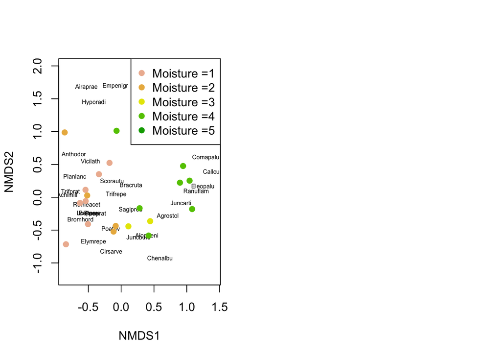

the first axis is broader than the second and, the first variable matches up with the first axis pretty well.

Species Eleopalu and Ranuflam are usually found close to one another in an area with a lot of higher level moisture points, whereas Achmill and Triforat are concentrated around lots of low moisture points

it seems like species on the left tend to line up more with lower levels of moisture, species towards the right of the plot line up more with higher levels pf moisture. showing there may be a strong correlation between moisture and where each specific species is found. However, some species appear without ant moisture level near them indicating not all variance is explained by moisture.

note. it computes between every sample a distance matrix, ignores where both are missing since it is a non euclidean method

# 2)Carry out a direct ordination using CCA in order to test any potential hypotheses that you developed after examining the MDS plot.

Canonical Correspondence Analysis (CCA) Let’s carry out a Canonical Correspondence Analysis (CCA) as well. CCA is appropriate for modeling unimodal or hump-shaped responses to explanatory variables (rather than linear as with RDA).

```r
cca_dune <- cca(dune ~ ., data=dune.env)
RsquareAdj(cca_dune, 100)
```

```
## $r.squared
## [1] 0.7106267
##
## $adj.r.squared
## [1] 0.2288484
```

```r
anova(cca_dune, permutations = 999)
```

```
## Permutation test for cca under reduced model
## Permutation: free
## Number of permutations: 999
##
## Model: cca(formula = dune ~ A1 + Moisture + Management + Use + Manure, data = dune.env)
##          Df ChiSquare      F Pr(>F)
## Model    12    1.5032 1.4325  0.032 *
## Residual  7    0.6121
## ---
## Signif. codes:  0 '***' 0.001 '**' 0.01 '*' 0.05 '.' 0.1 ' ' 1
```

```r
anova(cca_dune, by='margin', permutations = 999)
```

```
## Permutation test for cca under reduced model
## Marginal effects of terms
## Permutation: free
## Number of permutations: 999
##
## Model: cca(formula = dune ~ A1 + Moisture + Management + Use + Manure, data = dune.env)
##            Df ChiSquare      F Pr(>F)
## A1          1   0.11070 1.2660  0.242
## Moisture    3   0.31587 1.2041  0.208
## Management  2   0.15882 0.9081  0.536
## Use         2   0.13010 0.7439  0.765
## Manure      3   0.25490 0.9717  0.503
## Residual    7   0.61210
```

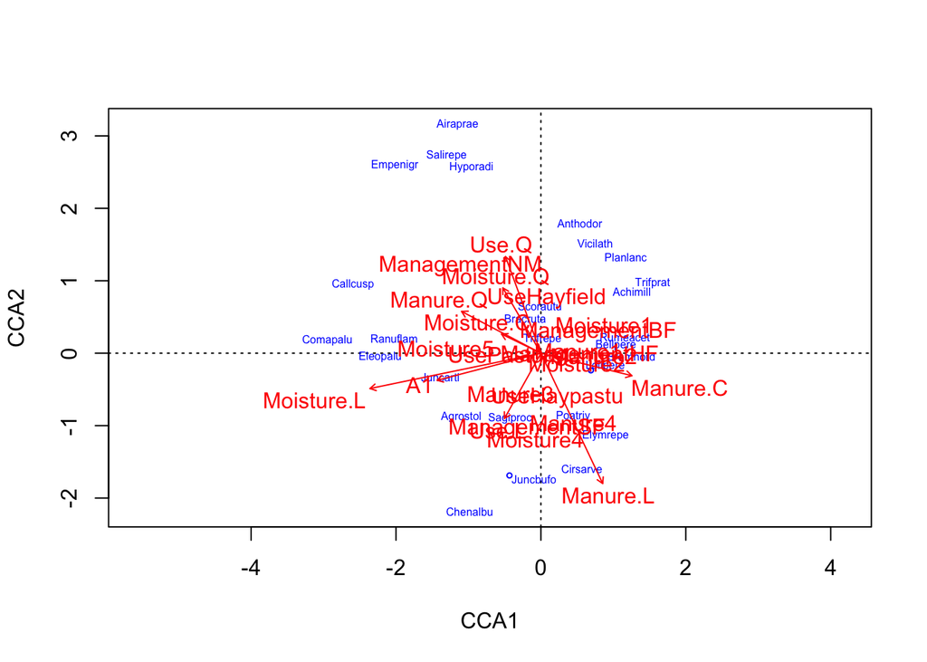

```r
plot(cca_dune, type='n', scaling=1)
orditorp(cca_dune, display='sp', cex=0.5, scaling=1, col='blue')
text(cca_dune, display='cn', col='red')
```

just moisture

```r
cca_dune_moisture <- cca(dune ~ dune.env$Moisture)
RsquareAdj(cca_dune_moisture, 100)
```

```
## $r.squared
## [1] 0.2970359
##
## $adj.r.squared
## [1] 0.1666945
```

```r
anova(cca_dune_moisture, permutations = 999)
```

```
## Permutation test for cca under reduced model
## Permutation: free
## Number of permutations: 999
##
## Model: cca(formula = dune ~ dune.env$Moisture)
##          Df ChiSquare      F Pr(>F)
## Model     3   0.62831 2.2536  0.001 ***
## Residual 16   1.48695
## ---
## Signif. codes:  0 '***' 0.001 '**' 0.01 '*' 0.05 '.' 0.1 ' ' 1
```

```r
anova(cca_dune_moisture, by='margin', permutations = 999)
```

```
## Permutation test for cca under NA model
## Marginal effects of terms
## Permutation: free
## Number of permutations: 999
##
## Model: cca(formula = dune ~ dune.env$Moisture)
##                   Df ChiSquare      F Pr(>F)
## dune.env$Moisture  3   0.62831 2.2536  0.001 ***
## Residual          16   1.48695
## ---
## Signif. codes:  0 '***' 0.001 '**' 0.01 '*' 0.05 '.' 0.1 ' ' 1
```

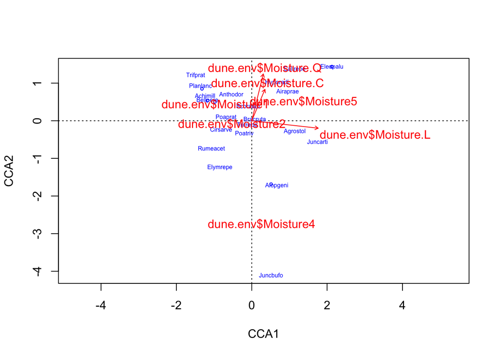

```r
plot(cca_dune_moisture, type='n', scaling=1)
orditorp(cca_dune_moisture, display='sp', cex=0.5, scaling=1, col='blue')
text(cca_dune_moisture, display='cn', col='red')
```

```r
dune.env$Moisture
```

```
##  [1] 1 1 2 2 1 1 1 5 4 2 1 4 5 5 5 5 2 1 5 5
## Levels: 1 < 2 < 4 < 5
```

```r
levels(dune.env$Moisture)
```

```
## [1] "1" "2" "4" "5"
```

Just A1

```r
cca_dune_A1 <- cca(dune ~ dune.env$A1)
RsquareAdj(cca_dune_A1, 100)
```

```
## $r.squared
## [1] 0.1062564
##
## $adj.r.squared
## [1] 0.05351661
```

```r
anova(cca_dune_A1, permutations = 999)
```

```
## Permutation test for cca under reduced model
## Permutation: free
## Number of permutations: 999
##
## Model: cca(formula = dune ~ dune.env$A1)
##          Df ChiSquare    F Pr(>F)
## Model     1   0.22476 2.14  0.031 *
## Residual 18   1.89050
## ---
## Signif. codes:  0 '***' 0.001 '**' 0.01 '*' 0.05 '.' 0.1 ' ' 1
```

```r
anova(cca_dune_A1, by='margin', permutations = 999)
```

```
## Permutation test for cca under NA model
## Marginal effects of terms
## Permutation: free
## Number of permutations: 999
##
## Model: cca(formula = dune ~ dune.env$A1)
##             Df ChiSquare    F Pr(>F)
## dune.env$A1  1   0.22476 2.14  0.026 *
## Residual    18   1.89050
## ---
## Signif. codes:  0 '***' 0.001 '**' 0.01 '*' 0.05 '.' 0.1 ' ' 1
```

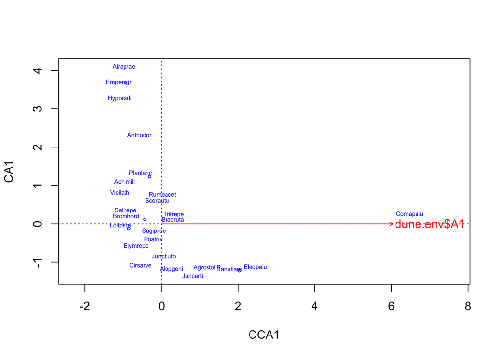

```r
plot(cca_dune_A1, type='n', scaling=1)
orditorp(cca_dune_A1, display='sp', cex=0.5, scaling=1, col='blue')
text(cca_dune_A1, display='bp', col='red')
```

Just manure

```r
cca_dune_Manure <- cca(dune ~ dune.env$Manure)
RsquareAdj(cca_dune_Manure, 100)
```

```
## $r.squared
## [1] 0.2891171
##
## $adj.r.squared
## [1] 0.1008452
```

```r
anova(cca_dune_Manure, permutations = 999)
```

```
## Permutation test for cca under reduced model
## Permutation: free
## Number of permutations: 999
##
## Model: cca(formula = dune ~ dune.env$Manure)
##          Df ChiSquare      F Pr(>F)
## Model     4   0.61156 1.5251  0.031 *
## Residual 15   1.50370
## ---
## Signif. codes:  0 '***' 0.001 '**' 0.01 '*' 0.05 '.' 0.1 ' ' 1
```

```r
anova(cca_dune_Manure, by='margin', permutations = 999)
```

```
## Permutation test for cca under NA model
## Marginal effects of terms
## Permutation: free
## Number of permutations: 999
##
## Model: cca(formula = dune ~ dune.env$Manure)
##                 Df ChiSquare      F Pr(>F)
## dune.env$Manure  4   0.61156 1.5251  0.035 *
## Residual        15   1.50370
## ---
## Signif. codes:  0 '***' 0.001 '**' 0.01 '*' 0.05 '.' 0.1 ' ' 1
```

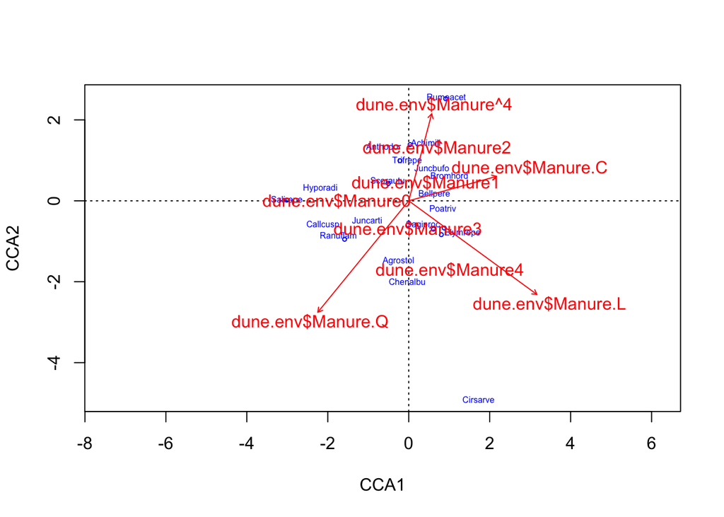

```r
plot(cca_dune_Manure, type='n', scaling=1)
orditorp(cca_dune_Manure, display='sp', cex=0.5, scaling=1, col='blue')
text(cca_dune_Manure, display='cn', col='red')
```

Just Management

```r
cca_dune_Management <- cca(dune ~ dune.env$Management)
RsquareAdj(cca_dune_Management, 100)
```

```
## $r.squared
## [1] 0.285467
##
## $adj.r.squared
## [1] 0.1475956
```

```r
anova(cca_dune_Management, permutations = 999)
```

```
## Permutation test for cca under reduced model
## Permutation: free
## Number of permutations: 999
##
## Model: cca(formula = dune ~ dune.env$Management)
##          Df ChiSquare      F Pr(>F)
## Model     3   0.60384 2.1307  0.002 **
## Residual 16   1.51143
## ---
## Signif. codes:  0 '***' 0.001 '**' 0.01 '*' 0.05 '.' 0.1 ' ' 1
```

```r
anova(cca_dune_Management, by='margin', permutations = 999)
```

```
## Permutation test for cca under NA model
## Marginal effects of terms
## Permutation: free
## Number of permutations: 999
##
## Model: cca(formula = dune ~ dune.env$Management)
##                     Df ChiSquare      F Pr(>F)
## dune.env$Management  3   0.60384 2.1307  0.002 **
## Residual            16   1.51143
## ---
## Signif. codes:  0 '***' 0.001 '**' 0.01 '*' 0.05 '.' 0.1 ' ' 1
```

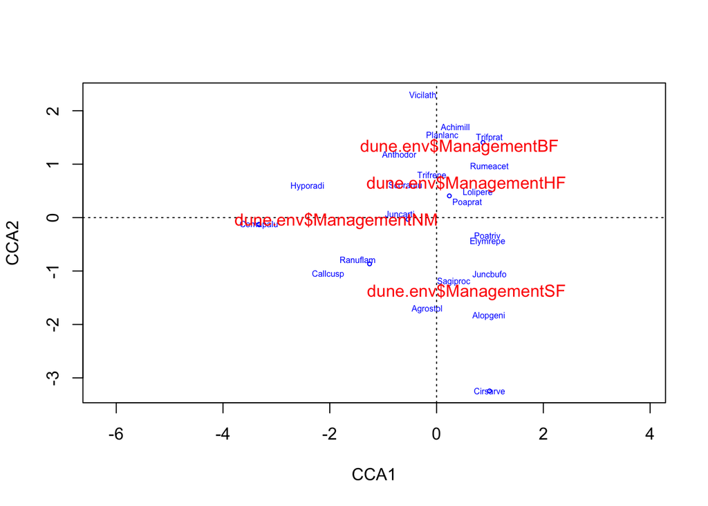

```r
plot(cca_dune_Management, type='n', scaling=1)
orditorp(cca_dune_Management, display='sp', cex=0.5, scaling=1, col='blue')
text(cca_dune_Management, display='cn', col='red')
```

Just Use

```r
cca_dune_Use <- cca(dune ~ dune.env$Use)
RsquareAdj(cca_dune_Use, 100)
```

```
## $r.squared
## [1] 0.1185381
##
## $adj.r.squared
## [1] 0.01845331
```

```r
anova(cca_dune_Use, permutations = 999)
```

```
## Permutation test for cca under reduced model
## Permutation: free
## Number of permutations: 999
##
## Model: cca(formula = dune ~ dune.env$Use)
##          Df ChiSquare      F Pr(>F)
## Model     2   0.25074 1.1431  0.263
## Residual 17   1.86452
```

```r
anova(cca_dune_Use, by='margin', permutations = 999)
```

```
## Permutation test for cca under NA model
## Marginal effects of terms
## Permutation: free
## Number of permutations: 999
##
## Model: cca(formula = dune ~ dune.env$Use)
##              Df ChiSquare      F Pr(>F)
## dune.env$Use  2   0.25074 1.1431  0.272
## Residual     17   1.86452
```

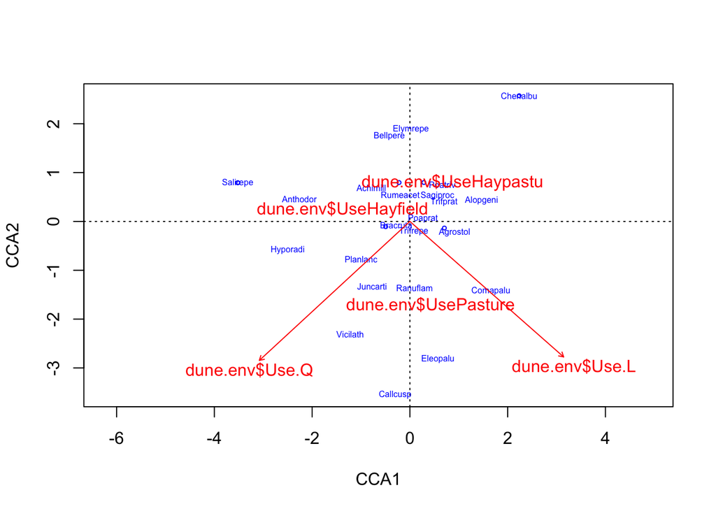

```r
plot(cca_dune_Use, type='n', scaling=1)
orditorp(cca_dune_Use, display='sp', cex=0.5, scaling=1, col='blue')
text(cca_dune_Use, display='cn', col='red')
```

vector moisture - the following two variables were changed to vectors in order to further analyze their individual/overall effects

```r
vector_moisture <- as.numeric(as.character(dune.env$Moisture))
vector_moisture
```

```
##  [1] 1 1 2 2 1 1 1 5 4 2 1 4 5 5 5 5 2 1 5 5
```

```r
dune.env$Moisture
```

```
##  [1] 1 1 2 2 1 1 1 5 4 2 1 4 5 5 5 5 2 1 5 5
## Levels: 1 < 2 < 4 < 5
```

```r
vector_moisture_cca <- cca(dune~vector_moisture)
RsquareAdj(vector_moisture_cca, 100)
```

```
## $r.squared
## [1] 0.1942555
##
## $adj.r.squared
## [1] 0.1504923
```

```r
anova(vector_moisture_cca, permutations = 999)
```

```
## Permutation test for cca under reduced model
## Permutation: free
## Number of permutations: 999
##
## Model: cca(formula = dune ~ vector_moisture)
##          Df ChiSquare      F Pr(>F)
## Model     1    0.4109 4.3396  0.001 ***
## Residual 18    1.7044
## ---
## Signif. codes:  0 '***' 0.001 '**' 0.01 '*' 0.05 '.' 0.1 ' ' 1
```

```r
anova(vector_moisture_cca, by='margin', permutations = 999)
```

```
## Permutation test for cca under NA model
## Marginal effects of terms
## Permutation: free
## Number of permutations: 999
##
## Model: cca(formula = dune ~ vector_moisture)
##                 Df ChiSquare      F Pr(>F)
## vector_moisture  1    0.4109 4.3396  0.001 ***
## Residual        18    1.7044
## ---
## Signif. codes:  0 '***' 0.001 '**' 0.01 '*' 0.05 '.' 0.1 ' ' 1
```

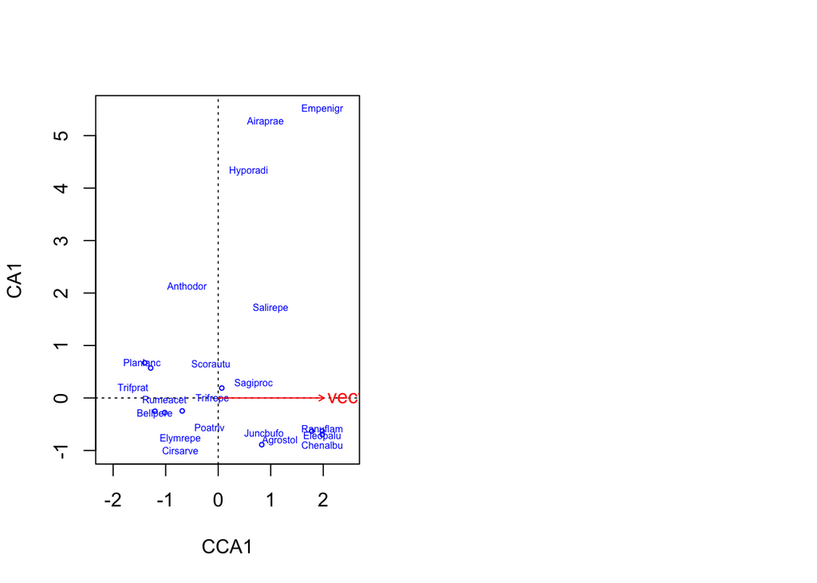

```r
par(mfrow=(c(1,2)))
plot(vector_moisture_cca, type='n', scaling=1)
orditorp(vector_moisture_cca, display='sp', cex=0.5, scaling=1, col='blue')
text(vector_moisture_cca, display='bp', col='red')
```

vector manure

```r
vector_manure <- as.numeric(as.character(dune.env$Manure))
vector_manure_cca <- cca(dune~vector_manure)
RsquareAdj(vector_manure_cca, 100)
```

```
## $r.squared
## [1] 0.112876
##
## $adj.r.squared
## [1] 0.06433433
```

```r
anova(vector_manure_cca, permutations = 999)
```

```
## Permutation test for cca under reduced model
## Permutation: free
## Number of permutations: 999
##
## Model: cca(formula = dune ~ vector_manure)
##          Df ChiSquare      F Pr(>F)
## Model     1   0.23876 2.2903  0.017 *
## Residual 18   1.87650
## ---
## Signif. codes:  0 '***' 0.001 '**' 0.01 '*' 0.05 '.' 0.1 ' ' 1
```

```r
anova(vector_manure_cca, by='margin', permutations = 999)
```

```
## Permutation test for cca under NA model
## Marginal effects of terms
## Permutation: free
## Number of permutations: 999
##
## Model: cca(formula = dune ~ vector_manure)
##               Df ChiSquare      F Pr(>F)
## vector_manure  1   0.23876 2.2903  0.008 **
## Residual      18   1.87650
## ---
## Signif. codes:  0 '***' 0.001 '**' 0.01 '*' 0.05 '.' 0.1 ' ' 1
```

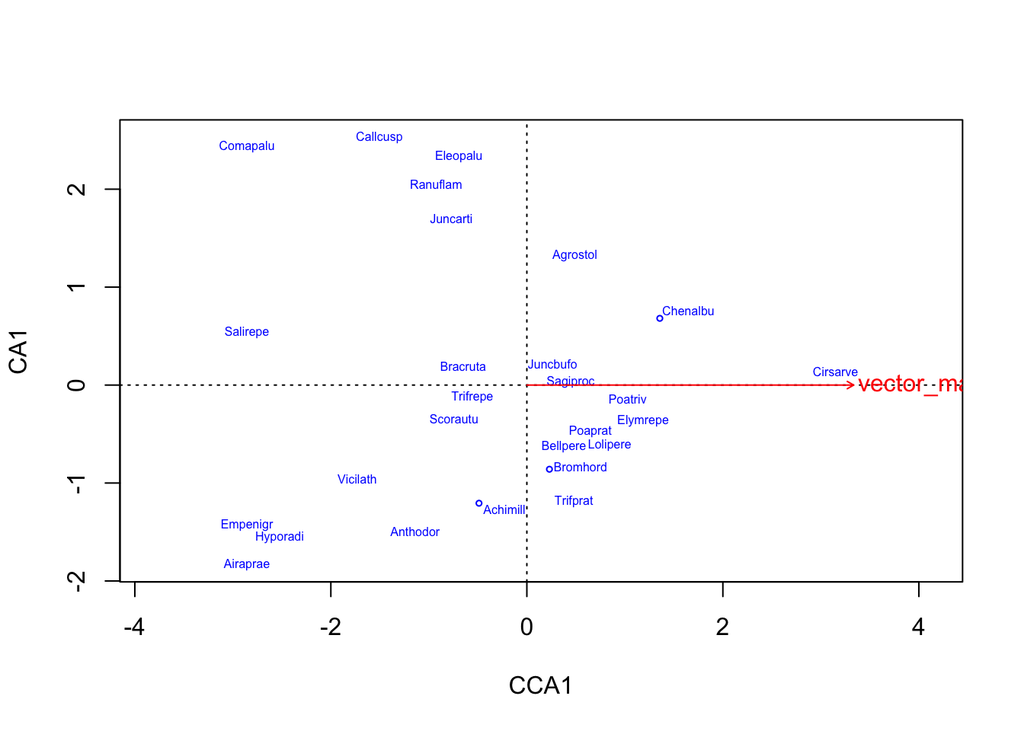

```r
plot(vector_manure_cca, type='n', scaling=1)
orditorp(vector_manure_cca, display='sp', cex=0.5, scaling=1, col='blue')
text(vector_manure_cca, display='bp', col='red')
```

new dune cca

```r
cca_dune_new <- cca(dune ~ A1 + Use + Management + vector_moisture + vector_manure, data=dune.env)
RsquareAdj(cca_dune_new, 100)
```

```
## $r.squared
## [1] 0.5766018
##
## $adj.r.squared
## [1] 0.2680269
```

```r
anova(cca_dune_new, permutations = 999)
```

```
## Permutation test for cca under reduced model
## Permutation: free
## Number of permutations: 999
##
## Model: cca(formula = dune ~ A1 + Use + Management + vector_moisture + vector_manure, data = dune.env)
##          Df ChiSquare      F Pr(>F)
## Model     8    1.2197 1.8725  0.001 ***
## Residual 11    0.8956
## ---
## Signif. codes:  0 '***' 0.001 '**' 0.01 '*' 0.05 '.' 0.1 ' ' 1
```

```r
anova(cca_dune_new, by='margin', permutations = 999)
```

```
## Permutation test for cca under reduced model
## Marginal effects of terms
## Permutation: free
## Number of permutations: 999
##
## Model: cca(formula = dune ~ A1 + Use + Management + vector_moisture + vector_manure, data = dune.env)
##                 Df ChiSquare      F Pr(>F)
## A1               1   0.11014 1.3528  0.185
## Use              2   0.13212 0.8114  0.734
## Management       3   0.31592 1.2934  0.148
## vector_moisture  1   0.18068 2.2191  0.023 *
## vector_manure    1   0.08973 1.1020  0.358
## Residual        11   0.89560
## ---
## Signif. codes:  0 '***' 0.001 '**' 0.01 '*' 0.05 '.' 0.1 ' ' 1
```

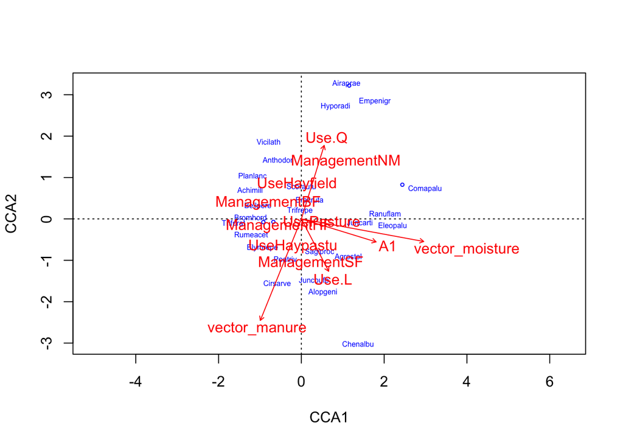

```r
plot(cca_dune_new, type='n', scaling=1)
orditorp(cca_dune_new, display='sp', cex=0.5, scaling=1, col='blue')
text(cca_dune_new, display='cn', col='red')
```

# 3) Do your two analyses agree with one another or complement one another or do these two analyses seem to be suggesting different take home messages? Which analysis do you find to be more useful?

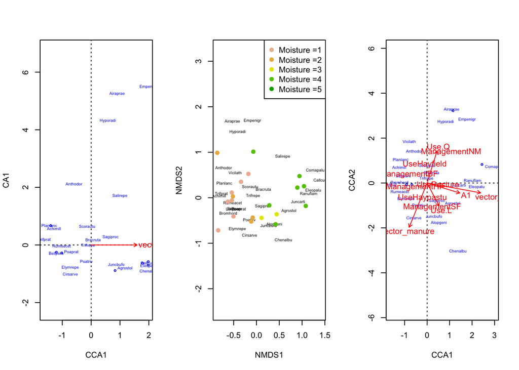

```r
par(mfrow=(c(1,3)))
plot(vector_moisture_cca, type='n', scaling=1)
orditorp(vector_moisture_cca, display='sp', cex=0.5, scaling=1, col='blue')
text(vector_moisture_cca, display='bp', col='red')

# compared with the nmds moisture graph
plot(dune_mds, type='n')
text(dune_mds, 'sp', cex=.5)
# generate vector of colors
color_vect <- rev(terrain.colors(6))[-1]
points(dune_mds, 'sites', pch=19,
       col=color_vect[dune.env$Moisture])
legend('topright', paste("Moisture =", 1:5, sep=''),
       col=color_vect, pch=19)
# also compared with overall cca analysis
plot(cca_dune_new, type='n', scaling=1)
orditorp(cca_dune_new, display='sp', cex=0.5, scaling=1, col='blue')
text(cca_dune_new, display='cn', col='red')
```

As seen above the CCA analysis of vector moisture and the NMDS analysis do seem to reperesent the same conclusions regarding moisture. This can be seen be the high positive correlation of Eleopaulu, Ranuflam, and Juncarti in the graphic of the CCA analysis, as well as their correspondence with moisture level five, a higher moisture level, shown by the NMDS analysis. This is further shown by the begative correlation of Tripfrat and Achmill in the CCA graph, as well as their correspondence with moisture level 1 and 2 in the nmds graph. Lastly, the high residual of Airaprae and Empenigr in the CCA graph coincides with their lack of correspondence with any moisture levels in the NMDS graph. This shows that there not much variance of these species is explained by moisture, and they are most likely affected more by other variables in the model.

# further CCA analysis

```r
RsquareAdj(cca_dune_new, 100)
```

```
## $r.squared
## [1] 0.5766018
##
## $adj.r.squared
## [1] 0.2695901
```

```r
RsquareAdj(cca_dune_A1, 100)
```

```
## $r.squared
## [1] 0.1062564
##
## $adj.r.squared
## [1] 0.0560652
```

```r
RsquareAdj(cca_dune_Management, 100)
```

```
## $r.squared
## [1] 0.285467
##
## $adj.r.squared
## [1] 0.1485902
```

```r
RsquareAdj(cca_dune_Use, 100)
```

```
## $r.squared
## [1] 0.1185381
##
## $adj.r.squared
## [1] 0.01544314
```

```r
RsquareAdj(cca_dune_moisture, 100)
```

```
## $r.squared
## [1] 0.2970359
##
## $adj.r.squared
## [1] 0.1684652
```

```r
RsquareAdj(cca_dune_Manure, 100)
```

```
## $r.squared
## [1] 0.2891171
##
## $adj.r.squared
## [1] 0.09387257
```

```r
RsquareAdj(vector_manure_cca, 100)
```

```
## $r.squared
## [1] 0.112876
##
## $adj.r.squared
## [1] 0.06458849
```

```r
RsquareAdj(vector_moisture_cca, 100)
```

```
## $r.squared
## [1] 0.1942555
##
## $adj.r.squared
## [1] 0.148031
```

should try removing use from model, only 1.6 rsquared adj chnaging to vectors, although better to visualize does decrease the r square, but increases adj r squre, so overall probably a better model even though individuallly the vectors have lower r squres than their counterparts they help to decrease the overfitting of the model due to an excess of variables

```r
without_use_cca <- update(cca_dune_new, . ~ . - Use)
par(mfrow=c(1,1))
RsquareAdj(without_use_cca, 100)
```

```
## $r.squared
## [1] 0.5141402
##
## $adj.r.squared
## [1] 0.295702
```

```r
anova(without_use_cca, permutations = 999)
```

```
## Permutation test for cca under reduced model
## Permutation: free
## Number of permutations: 999
##
## Model: cca(formula = dune ~ A1 + Management + vector_moisture + vector_manure, data = dune.env)
##          Df ChiSquare      F Pr(>F)
## Model     6    1.0875 2.2928  0.001 ***
## Residual 13    1.0277
## ---
## Signif. codes:  0 '***' 0.001 '**' 0.01 '*' 0.05 '.' 0.1 ' ' 1
```

```r
anova(without_use_cca, by='margin', permutations = 999)
```

```
## Permutation test for cca under reduced model
## Marginal effects of terms
## Permutation: free
## Number of permutations: 999
##
## Model: cca(formula = dune ~ A1 + Management + vector_moisture + vector_manure, data = dune.env)
##                 Df ChiSquare      F Pr(>F)
## A1               1   0.15023 1.9003  0.040 *
## Management       3   0.31830 1.3421  0.102
## vector_moisture  1   0.22460 2.8411  0.003 **
## vector_manure    1   0.08155 1.0316  0.398
## Residual        13   1.02772
## ---
## Signif. codes:  0 '***' 0.001 '**' 0.01 '*' 0.05 '.' 0.1 ' ' 1
```

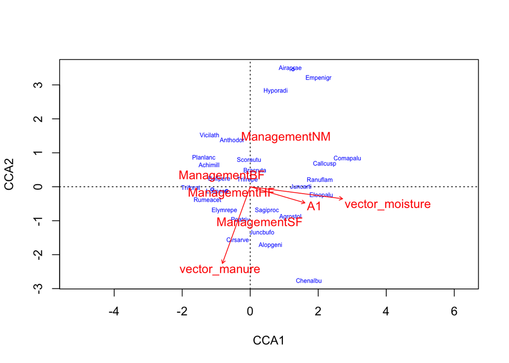

```r
plot(without_use_cca, type='n', scaling=1)
orditorp(without_use_cca, display='sp', cex=0.5, scaling=1, col='blue')
text(without_use_cca, display='cn', col='red')
```

manure plot like moisture nmds

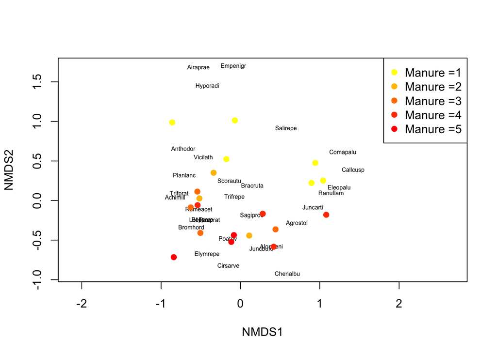

```r
plot(dune_mds, type='n')
text(dune_mds, 'sp', cex=.5)
# generate vector of colors
color_vect = rev(heat.colors(6))[-1]
points(dune_mds, 'sites', pch=19,
       col=color_vect[dune.env$Manure])
legend('topright', paste("Manure =", 1:5, sep=''),
       col=color_vect, pch=19)
```

```r
# dune.env$Manure
```

this further shows the correlation between the cca and nmds ordination results.